# Assignment3: Supervised Learning Competition - Group 11

Authors

Lourenço Santos Moitinho de Almeida

Liam Thomassen

Tim Rentenaar

Erdem Koçer

Published

October 21, 2023

## Data Description & Data Exploration

In order to predict student performance using the various characteristics of the students, we begin our analysis by exploring our dataset. Our exploratory data analysis will roughly follow the guidelines stated by Tukey and Peng. With that said, in order to get a preliminary understanding of our data, we ran the `str()` command as shown below in *Table 1*:

**Table 1:** Checking the Packaging of the Dataset using `str()`

```r
str(train_data)
```

```
tibble [316 × 31] (S3: tbl_df/tbl/data.frame)
 $ school    : Factor w/ 2 levels "GP","MS": 1 1 1 1 1 1 1 1 1 1 ...
 $ sex       : Factor w/ 2 levels "F","M": 1 1 2 2 1 1 2 1 1 2 ...
 $ age       : num [1:316] 18 17 17 18 16 15 15 15 16 15 ...
 $ address   : Factor w/ 2 levels "U","R": 1 1 1 2 1 2 1 1 1 1 ...
 $ famsize   : Factor w/ 2 levels "GT3","LE3": 1 1 1 1 1 2 2 1 1 1 ...
 $ Pstatus   : Factor w/ 2 levels "A","T": 2 2 2 2 2 2 2 2 2 2 ...
 $ Medu      : num [1:316] 3 3 2 4 1 2 3 4 3 2 ...
 $ Fedu      : num [1:316] 2 4 3 3 3 2 3 4 3 3 ...
 $ Mjob      : Factor w/ 5 levels "at_home","health",..: 3 4 3 5 1 2 3 4 3 3 ...
 $ Fjob      : Factor w/ 5 levels "teacher","other",..: 3 2 2 3 3 3 2 5 2 2 ...
 $ reason    : Factor w/ 4 levels "course","other",..: 2 1 1 1 3 4 1 1 3 3 ...
 $ guardian  : Factor w/ 3 levels "mother","father",..: 1 1 2 1 1 1 1 1 1 1 ...
 $ traveltime: num [1:316] 1 1 2 1 1 2 1 1 1 1 ...
 $ studytime : num [1:316] 3 3 1 3 2 2 2 3 3 3 ...
```

[output cut: 17 more lines]

```r
factor_cols <- names(train_data)[sapply(train_data, is.factor)]
num_cols <- names(train_data)[sapply(train_data, is.numeric)]
```

This training dataset contains 316 rows and 31 columns. Furthermore, the column `score` represents our dependent variable while the rest of the columns are explanatory variables. This dataset contains two types of variables: factor (categorial) and numerical variables. Each column can be categorized into one of the two variables types:

- Factor Variables: school, sex, address, famsize, Pstatus, Mjob, Fjob, reason, guardian, schoolsup, famsup, paid, activities, nursery, higher, internet, romantic
- Numerical Variables: age, Medu, Fedu, traveltime, studytime, failures, famrel, freetime, goout, Dalc, Walc, health, absences, score

Additionally, *Figure 1* dispalys that this dataset doesn’t contain any missing values. Therefore, any missing information imputation strategies won’t be required during the data (pre)processing step of our analysis.

**Figure 1:** Counts of all the Missing Data per Column

```r
sapply(train_data, function(x) sum(is.na(x)))
```

```
    school        sex        age    address    famsize    Pstatus       Medu
         0          0          0          0          0          0          0
      Fedu       Mjob       Fjob     reason   guardian traveltime  studytime
         0          0          0          0          0          0          0
  failures  schoolsup     famsup       paid activities    nursery     higher
         0          0          0          0          0          0          0
  internet   romantic     famrel   freetime      goout       Dalc       Walc
         0          0          0          0          0          0          0
    health   absences      score
         0          0          0
```

An important thing to note is that despite the insights given by running the `str()` command, reading the column descriptions file gives contradicting information. For instance out of the 14 numeric columns, only `age`, `absences` and `score` are ‘true’ numericcal variables. The rest of the variables are ordinal variables such as `Dalc`, a variable ranging from 1-5 based on workday alcohol consumption. This assessment is further backed up by analysing the top and bottom of the dataset as shown below in *Table 2* and *Table 3*:

**Table 2:** Top of the Dataset

```r
head(train_data)
```

| school | sex | age | address | famsize | Pstatus | Medu | Fedu | Mjob | Fjob | reason | guardian | traveltime | studytime | failures | schoolsup | famsup | paid | activities | nursery | higher | internet | romantic | famrel | freetime | goout | Dalc | Walc | health | absences | … |
| --- | --- | --- | --- | --- | --- | --- | --- | --- | --- | --- | --- | --- | --- | --- | --- | --- | --- | --- | --- | --- | --- | --- | --- | --- | --- | --- | --- | --- | --- | --- |
| GP | F | 18 | U | GT3 | T | 3 | 2 | other | services | other | mother | 1 | 3 | 0 | no | no | no | no | yes | yes | yes | yes | 5 | 4 | 3 | 2 | 3 | 1 | 7 | … |
| GP | F | 17 | U | GT3 | T | 3 | 4 | services | other | course | mother | 1 | 3 | 0 | no | no | no | no | yes | yes | yes | no | 4 | 4 | 5 | 1 | 3 | 5 | 16 | … |
| GP | M | 17 | U | GT3 | T | 2 | 3 | other | other | course | father | 2 | 1 | 0 | no | no | no | no | yes | yes | yes | no | 5 | 2 | 2 | 1 | 1 | 2 | 4 | … |
| GP | M | 18 | R | GT3 | T | 4 | 3 | teacher | services | course | mother | 1 | 3 | 0 | no | no | no | no | yes | yes | yes | yes | 5 | 3 | 2 | 1 | 2 | 4 | 9 | … |
| GP | F | 16 | U | GT3 | T | 1 | 3 | at_home | services | home | mother | 1 | 2 | 3 | no | no | no | yes | no | yes | yes | yes | 4 | 3 | 5 | 1 | 1 | 3 | 0 | … |
| GP | F | 15 | R | LE3 | T | 2 | 2 | health | services | reputation | mother | 2 | 2 | 0 | yes | yes | yes | no | yes | yes | yes | no | 4 | 1 | 3 | 1 | 3 | 4 | 2 | … |

**Table 3:** Bottom of the Dataset

```r
tail(train_data)
```

| school | sex | age | address | famsize | Pstatus | Medu | Fedu | Mjob | Fjob | reason | guardian | traveltime | studytime | failures | schoolsup | famsup | paid | activities | nursery | higher | internet | romantic | famrel | freetime | goout | Dalc | Walc | health | absences | … |
| --- | --- | --- | --- | --- | --- | --- | --- | --- | --- | --- | --- | --- | --- | --- | --- | --- | --- | --- | --- | --- | --- | --- | --- | --- | --- | --- | --- | --- | --- | --- |
| GP | F | 17 | U | GT3 | T | 4 | 2 | other | other | reputation | mother | 2 | 3 | 0 | no | yes | yes | no | yes | yes | yes | no | 4 | 3 | 3 | 1 | 1 | 3 | 0 | … |
| GP | M | 15 | R | GT3 | T | 4 | 3 | teacher | at_home | course | mother | 1 | 2 | 0 | no | yes | no | yes | yes | yes | yes | yes | 4 | 5 | 2 | 1 | 1 | 5 | 0 | … |
| GP | M | 17 | U | LE3 | T | 4 | 4 | other | teacher | home | father | 2 | 1 | 0 | no | no | yes | no | yes | yes | yes | no | 4 | 1 | 1 | 2 | 2 | 5 | 0 | … |
| GP | M | 16 | U | GT3 | T | 4 | 4 | services | services | other | mother | 1 | 1 | 0 | yes | yes | yes | yes | yes | yes | yes | no | 4 | 5 | 5 | 5 | 5 | 4 | 14 | … |
| MS | F | 17 | R | GT3 | T | 3 | 1 | at_home | other | reputation | mother | 1 | 2 | 0 | no | yes | yes | yes | no | yes | yes | no | 4 | 5 | 4 | 2 | 3 | 1 | 17 | … |
| GP | F | 15 | U | GT3 | T | 4 | 4 | teacher | health | reputation | mother | 1 | 2 | 0 | no | yes | yes | no | yes | yes | yes | no | 3 | 3 | 3 | 1 | 2 | 2 | 0 | … |

### The Analysis for the Dependent Variable: Score

```r
minimum_value <- round(min(train_data$score), 2)
maximum_value <- round(max(train_data$score), 2)
median_value <- round(median(train_data$score), 2)
q1_value <- round(quantile(train_data$score, 0.25), 2)
q3_value <- round(quantile(train_data$score, 0.75), 2)
```

The whole aim of this analysis is to predict scores for students in the test dataset. In order to do so we took a closer look at the variable `score`. Below, *Figure 2* displays the spread of `score` in addition to a 5-number summary. Following the inter-quartile range rule for outlier detection, scores outside the range of $-2.535\leq x \leq 2.545$ would be considered outliers.

**Figure 2:** The Spread and 5-Number Summary of `score`

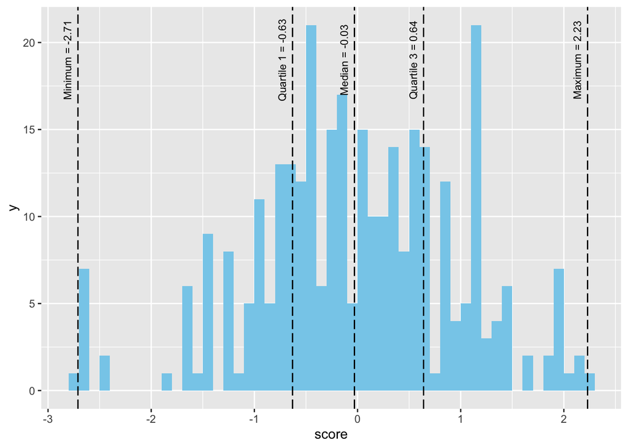

```r
# I made 3 graphs. Either pick one or multiple or make a new one!!!
train_data |> ggplot(aes(x=score)) +
  geom_histogram(fill = "skyblue", breaks = pretty(train_data$score, n=50)) +
  geom_vline(xintercept = minimum_value, colour = "black", linetype = "longdash") +
  annotate(geom = "text", label = paste("Minimum =", minimum_value), color = "black", angle = 90, x = minimum_value-0.1, y = 19, size = 3) +
  geom_vline(xintercept = maximum_value, colour = "black", linetype = "longdash") +
  annotate(geom = "text", label = paste("Maximum =", maximum_value), color = "black", angle = 90, x = maximum_value-0.1, y = 19, size = 3) +
  geom_vline(xintercept = median_value, colour = "black", linetype = "longdash") +
  annotate(geom = "text", label = paste("Median =", median_value), color = "black", angle = 90, x = median_value-0.1, y = 19, size = 3) +
  geom_vline(xintercept = q1_value, colour = "black", linetype = "longdash") +
  annotate(geom = "text", label = paste("Quartile 1 =", q1_value), color = "black", angle = 90, x = q1_value-0.1, y = 19, size = 3) +
  geom_vline(xintercept = q3_value, colour = "black", linetype = "longdash") +
  annotate(geom = "text", label = paste("Quartile 3 =", q3_value), color = "black", angle = 90, x = q3_value-0.1, y = 19, size = 3)
```

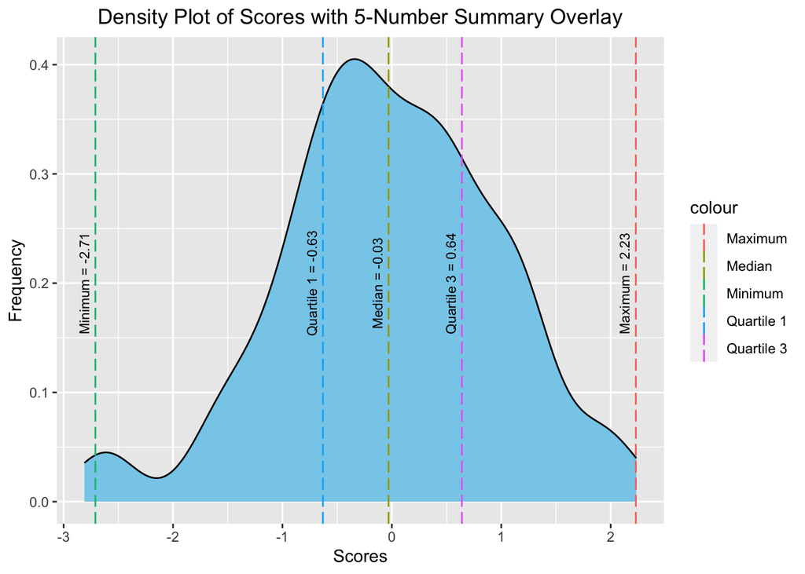

```r
ggplot(train_data, aes(x = score)) +
  geom_density(fill = "skyblue") +
  xlab("Scores") +
  ylab("Frequency") +
  ggtitle("Density Plot of Scores with 5-Number Summary Overlay") +
  theme(plot.title = element_text(hjust = 0.5)) +

  geom_vline(aes(xintercept = minimum_value, color = "Minimum"), linetype = "longdash") +
  annotate(geom = "text", label = paste("Minimum =", minimum_value), color = "black", angle = 90, x = minimum_value-0.1, y = 0.2, size = 3) +

  geom_vline(aes(xintercept = maximum_value, color = "Maximum"), linetype = "longdash") +
  annotate(geom = "text", label = paste("Maximum =", maximum_value), color = "black", angle = 90, x = maximum_value-0.1, y = 0.2, size = 3) +

  geom_vline(aes(xintercept = median_value, color = "Median"), linetype = "longdash") +
  annotate(geom = "text", label = paste("Median =", median_value), color = "black", angle = 90, x = median_value-0.1, y = 0.2, size = 3) +

  geom_vline(aes(xintercept = q1_value, color = "Quartile 1"), linetype = "longdash") +
  annotate(geom = "text", label = paste("Quartile 1 =", q1_value), color = "black", angle = 90, x = q1_value-0.1, y = 0.2, size = 3) +

  geom_vline(aes(xintercept = q3_value, color = "Quartile 3"), linetype = "longdash") +
  annotate(geom = "text", label = paste("Quartile 3 =", q3_value), color = "black", angle = 90, x = q3_value-0.1, y = 0.2, size = 3)
```

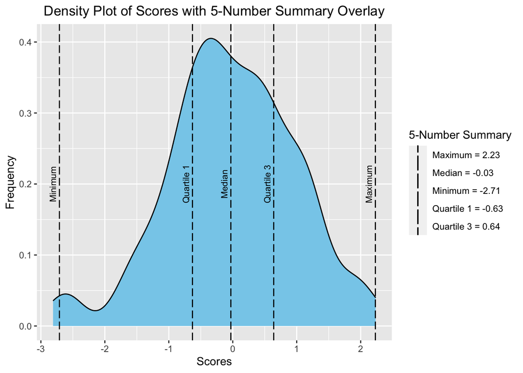

```r
ggplot(train_data, aes(x = score)) +
  geom_density(fill = "skyblue") +
  xlab("Scores") +
  ylab("Frequency") +
  ggtitle("Density Plot of Scores with 5-Number Summary Overlay") +
  theme(plot.title = element_text(hjust = 0.5)) +

  geom_vline(aes(xintercept = minimum_value, color = "Minimum = -2.71"), linetype = "longdash") +
  annotate(geom = "text", label = "Minimum", color = "black", angle = 90, x = minimum_value-0.1, y = 0.2, size = 3) +

  geom_vline(aes(xintercept = maximum_value, color = "Maximum = 2.23"), linetype = "longdash") +
  annotate(geom = "text", label = "Maximum", color = "black", angle = 90, x = maximum_value-0.1, y = 0.2, size = 3) +

  geom_vline(aes(xintercept = median_value, color = "Median = -0.03"), linetype = "longdash") +
  annotate(geom = "text", label = "Median", color = "black", angle = 90, x = median_value-0.1, y = 0.2, size = 3) +

  geom_vline(aes(xintercept = q1_value, color = "Quartile 1 = -0.63"), linetype = "longdash") +
  annotate(geom = "text", label = "Quartile 1", color = "black", angle = 90, x = q1_value-0.1, y = 0.2, size = 3) +

  geom_vline(aes(xintercept = q3_value, color = "Quartile 3 = 0.64"), linetype = "longdash") +
  annotate(geom = "text", label = "Quartile 3", color = "black", angle = 90, x = q3_value-0.1, y = 0.2, size = 3) +

  scale_color_manual("5-Number Summary", values = c("Minimum = -2.71" = "black", "Maximum = 2.23" = "black", "Median = -0.03" = "black", "Quartile 1 = -0.63" = "black", "Quartile 3 = 0.64" = "black"))
```

### Correlation between Score and the Explanatory Variables

**Note:** Do we remove the correlated variables for the analysis and models?

**Table 4:** Correlation Matrix between Numerical Variables and `score`

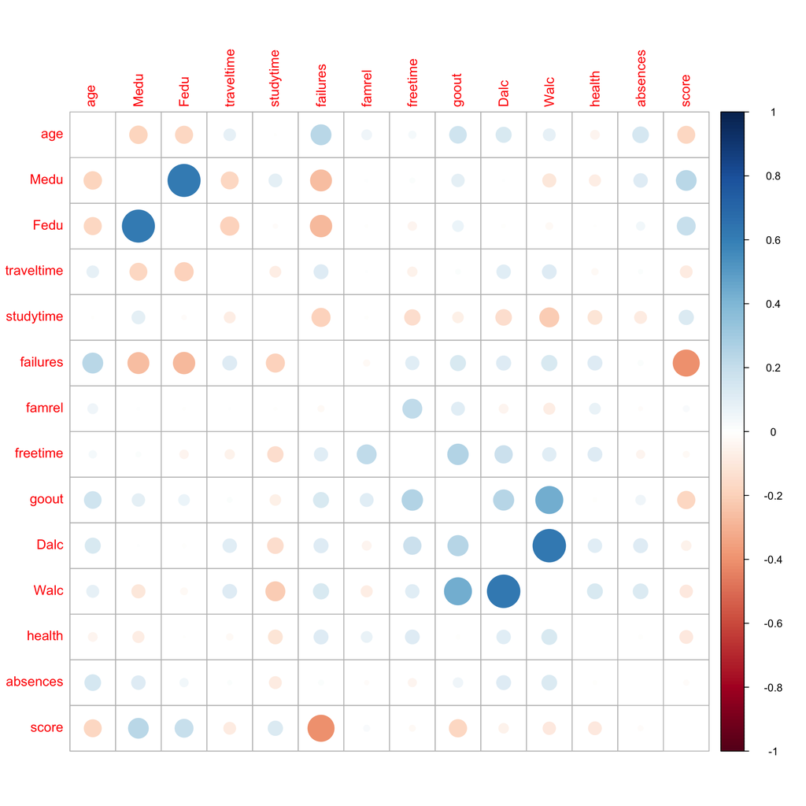

```r
corrplot(cor(train_data[sapply(train_data, is.numeric)]), diag = FALSE)
```

**Table 5:** Correlation Matrix between Converted Categorical Variables and `score`

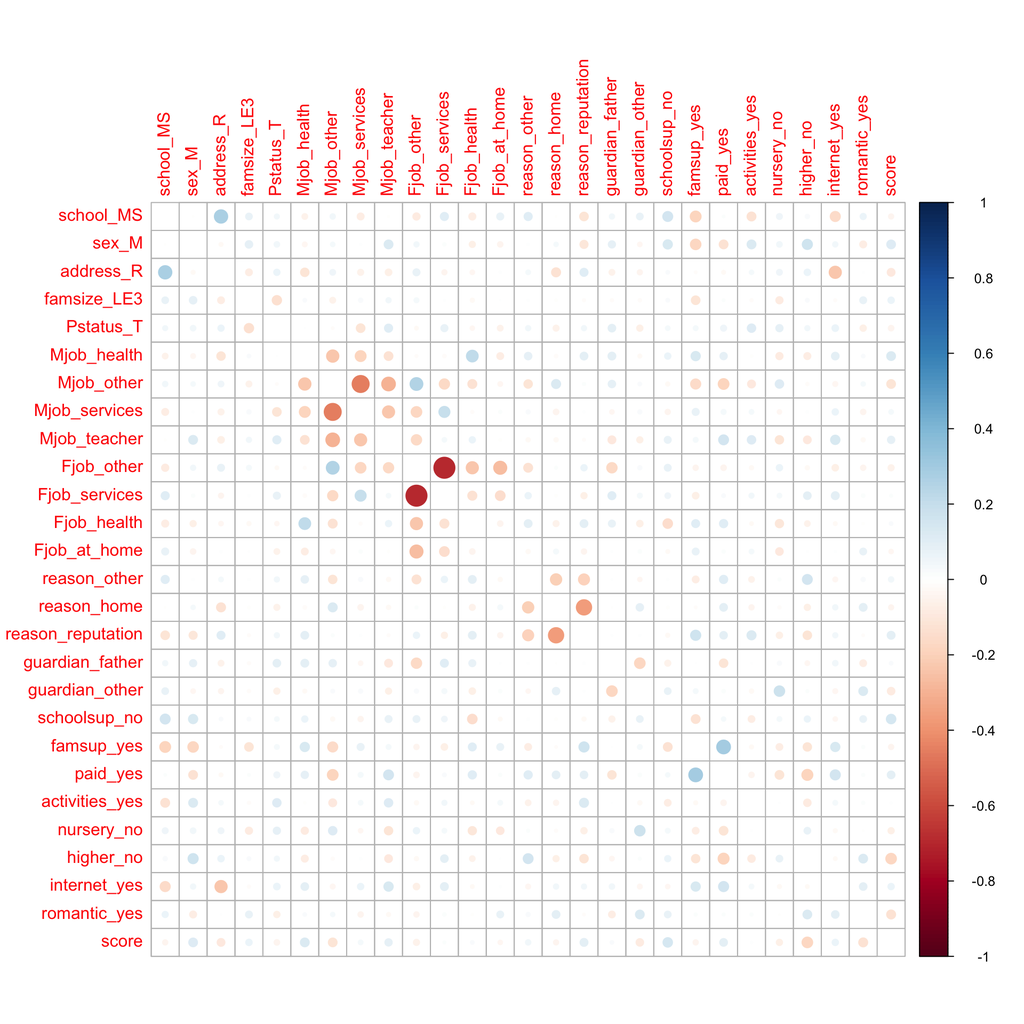

```r
temp_df <- train_data[, !sapply(train_data, is.numeric)]
temp_df_dummy <- dummy_cols(temp_df,remove_first_dummy=TRUE,remove_selected_columns=TRUE)
temp_df_dummy$score <- train_data$score

corrplot(cor(temp_df_dummy), diag = FALSE)
```

## Model Description

1. Linear Regression
2. Regularized Regression
- use lasso, ridge or something better
3. Some tree-based model
- e.g. random forest
4. Attempt Neural Network

## Data Preprocessing & Transformation

- forward and backward feature selection for regression?
1. Convert variables into correct data types
2. Find statistically significant independent variables
3. One-hot encoding for categorial variables (ordinal encoding for ordinal variables?)
4. Data Reduction
- dimensionality reduction
- remove correlated variables
5. Some type of scaling for `score`?
- z-score/min-max

```r
train_data_dummy <- dummy_cols(train_data,remove_first_dummy=TRUE,remove_selected_columns=TRUE)
#train_data_dummy
```

```r
set.seed(1)

#Use 70% of dataset as training set and remaining 30% as testing set
sample <- sample(c(TRUE, FALSE), nrow(train_data_dummy), replace=TRUE, prob=c(0.9,0.1))
train  <- train_data_dummy[sample, ]
test   <- train_data_dummy[!sample, ]
```

```r
X_train <- train[, -which(names(train) == "score")]
y_train <- data.frame(train$score)
```

```r
X_test <- test[, -which(names(train) == "score")]
y_test <- test$score
```

```r
predict_linreg = lm(score~.,data=train)
#summary(predict_linreg)
y_pred_lin_reg <- predict(predict_linreg,newdata=test)

# Calculate the Mean Squared Error (MSE)
mean((y_pred_lin_reg - y_test)^2)
```

```
[1] 0.6129449
```

## Model Comparison

1. Models 1.1 Linear Regression 1.2 Ridge Regression 1.3 Tree 1.4 Neural Network
2. Comparison
- MSE, Train-Val-Test Split (lab 12), Neural Networks have their own special evaluation, ROC curve, AUC

```r
# creating a mean trivial baseline is not possible with the caret package
# the mean trivial baseline will be created with a single train/dev split

sample_size <- floor(0.8 * nrow(train_data_dummy))

set.seed(1234)

train_index <- sample(seq_len(nrow(train_data_dummy)), size=sample_size)

train_dummy_train <- train_data_dummy[train_index,]

train_dummy_dev <- train_data_dummy[-train_index,]

mean_score_train <- mean(train_dummy_train$score)
```

```r
# resulting Mean Absolute Error from the mean trivial baseline
abserror <- abs(train_dummy_dev$score - mean_score_train)
mae <- mean(abserror)
print(mae)
```

```
[1] 0.8114595
```

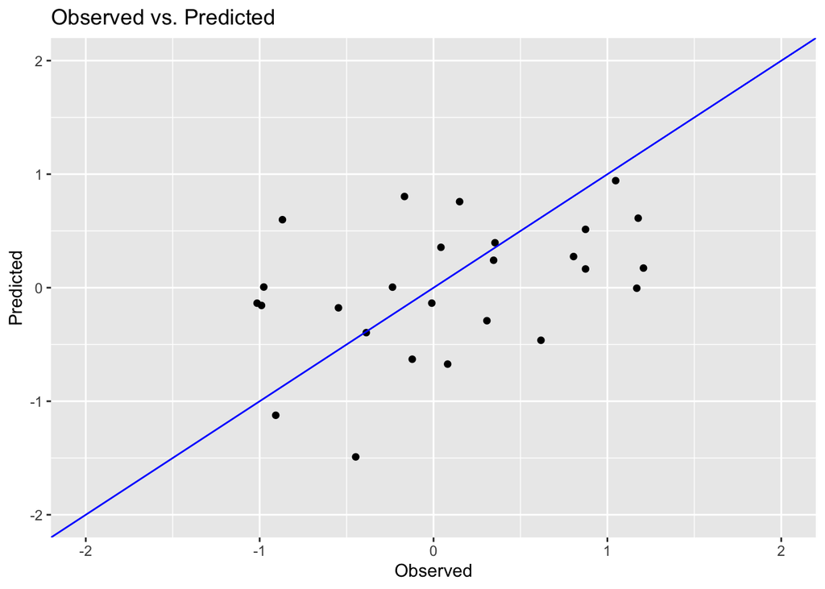

```r
ggplot(data=NULL, aes(x=y_test,y=y_pred_lin_reg)) +
  geom_point()+
  geom_abline(intercept = 0, slope = 1, color = "blue") +
  labs(x = "Observed", y = "Predicted") +
  ggtitle("Observed vs. Predicted") +
  xlim(c(-2,2)) +
  ylim(c(-2,2))
```

## Chosen Model

- focus on MSE